# Are Natural Disasters an Indicator of Economic Crisis?

### Introduction:

The world is undoubtedly getting warmer. According to a 2020 report by the World Meteorological Organization (WMO), the global mean surface temperature last year was approximately 1.2°C warmer than the pre-industrial baseline (1850-1900), and the most recent decade was the warmest on record. Throughout my project, I will be using the 'Climate Change: Earth Surface Temperature Data' to analyse and discover any drastic changes in regards to the increase in land or water temperature over time. I will use my findings and explore any natural disasters that have occured during those time periods. Overall, I am looking to find the time frame where we can see the highest increase in average land or sea temperature and figure out the reasons for these spikes in temperatures and their implications. Climate change can increase the risk of natural disasters in many ways, we know that it influences global temperature and precipitation patterns. This paper will specifically explore the direct relationship between natural disasters and global debt and argue that the rise in natural disasters due to climate change will result in higher global debt. With the steady rise in global surface temperatures, there will be a significant impact on the number, frequency, and duration of natural disasters, such as forest fires, hurricanes, heat waves, floods, droughts, and storms. For example, as more water vapour is evaporated into the atmosphere it becomes fuel for more powerful storms to develop. More heat in the atmosphere and warmer ocean surface temperatures can lead to increased wind speeds and tropical storms. Oxfam estimates the number of climate-related disasters has tripled in the last 30 years, and that more than 20 million people are being forced from their homes by climate change each year. This alarming number attests to the great impact global warming actually has on people's daily lives and is an issue that must be prioritised over the next couple of years.

### Background:

Temperatures measured on land and at sea show that Earth's average surface temperature is rising. Land surface temperature is not the same as air temperature since the land surface heats and cools more quickly than air. Many physical properties have an impact on land surface temperature, such as: vegetation density, soil moisture and humidity, and snow cover or rainfall. Heat trapped by greenhouse gases stays near the land surface as well as being stored in the ocean. For this reason, the combination of land and ocean surface temperature data is a better indicator of global warming than air temperature. We might notice bigger changes in land temperature rather than water temperature due to water evaporation which occurs in liquid state. Oceans can cool themselves in a warming climate by evaporating water with only a small temperature increase, while on the other hand, land has a smaller heat capacity than water, which means it needs less heat to raise its temperature.

### About the Dataset:

I am using dataset taken from kaggle.com compiled together by Berkley Earth. It combines 1.6 billion temperature reports from 16 pre-existing archives. There are 5 seperate datasets which include Global, Land and Ocean,and Land Temperatures which are sub-divided by: country, state, major city and city. This data set touches upon both land and ocean temperature data. However, it mainly focuses on land temperature as it is a more reliable measure and will experience more visible changes. However I will be adding additional datasets throughout the different stages of the projects.

## Project 1

```python
#importing packages
import pandas as pd
import matplotlib.pyplot as plt
%matplotlib inline
import datetime as dt
import numpy as np
import plotly.offline as py
py.init_notebook_mode(connected=True)
```

### Downloading and Cleaning the Data

First I am going to load all the different data sets onto jupyter notebook and clean it to make sure I have no missing values. I am choosing to disregard these comapared to editing them, because I don't want to bias my existing data with false predictions. It will also be easier to analyse the data wihtout focusing on the missing values.

```python
#Load global and land temperatures by city
city_dta = pd.read_csv('/Users/emidobak/Desktop/ECO225/Project/Data/GlobalLandTemperaturesByCity.csv')
city_dta.rename(columns = {'dt':'Date'}, inplace = True)
city_dta = city_dta.dropna()

#Load global and land temperatures by country
country_dta = pd.read_csv('/Users/emidobak/Desktop/ECO225/Project/Data/GlobalLandTemperaturesByCountry.csv')
country_dta.rename(columns = {'dt':'Date'}, inplace = True)
country_dta = country_dta.dropna()

#Global temperatures data
global_temp = pd.read_csv('/Users/emidobak/Desktop/ECO225/Project/Data/GlobalTemperatures.csv')
global_temp.rename(columns = {'dt':'Date'}, inplace = True)
global_temp = global_temp.dropna()
```

```python
#Finding the range of the data
print(city_dta.Date.min())
print(city_dta.Date.max())
```

```
1743-11-01
2013-09-01
```

From the output we can see that we have data in the range of 1743-2013, this indicates a span of 270 years. The global temperature dataset doesn't have data points for roughly the first 100 years, therefore, I will start my analysis from the year 1850. Similarly, we can question the realiance of the tools used to collect data from the land and ocean pre 1800's. For that reason, I will keep my analysis at a more recent time frame, in case of there being any false or accidentally innacurate data points.

```python
#Creating columns for Month and Year for global_temp
global_temp["Date"] = pd.to_datetime(global_temp["Date"])
global_temp["Month"] = global_temp["Date"].dt.month
global_temp["Year"] = global_temp["Date"].dt.year
```

### Summary Statistics of the Data

```python
#Summary statistics of global_temp data
summary = global_temp.groupby(by ='Year')[['LandAverageTemperature', 'LandAverageTemperatureUncertainty',
       'LandMaxTemperature', 'LandMaxTemperatureUncertainty', 'LandMinTemperature', 'LandMinTemperatureUncertainty',
       'LandAndOceanAverageTemperature', 'LandAndOceanAverageTemperatureUncertainty']].mean().reset_index()
summary[['LandAverageTemperature', 'LandMaxTemperature',
'LandMinTemperature', 'LandAndOceanAverageTemperature']].describe()
```

|  | LandAverageTemperature | LandMaxTemperature | LandMinTemperature | LandAndOceanAverageTemperature |
| --- | --- | --- | --- | --- |
| count | 166.000000 | 166.000000 | 166.000000 | 166.000000 |
| mean | 8.571583 | 14.350601 | 2.743595 | 15.212566 |
| std | 0.473687 | 0.447741 | 0.614124 | 0.298629 |
| min | 7.558583 | 13.081000 | 1.525083 | 14.740083 |
| 25% | 8.195708 | 14.055917 | 2.262562 | 14.991208 |
| 50% | 8.540750 | 14.307708 | 2.734917 | 15.144208 |
| 75% | 8.791250 | 14.539167 | 3.126833 | 15.379104 |
| max | 9.831000 | 15.572667 | 4.148833 | 16.058583 |

```python
#Creating columns for Month and Year
country_dta["Date"] = pd.to_datetime(country_dta["Date"])
country_dta["Month"] = country_dta["Date"].dt.month
country_dta["Year"] = country_dta["Date"].dt.year
```

```python
#group by year
gbY = country_dta.groupby('Year')
#Group by country
gbC = country_dta.groupby('Country')
#gbC.get_group('')
#gbY.get_group()
```

### Finding the 10 Countries with the Highest and Lowest Average Temperatures

###### Figure 1

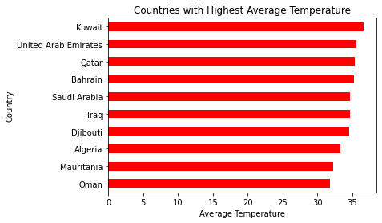

```python
#10 countries with highest temperatures
ax = country_dta.groupby(['Country'])['AverageTemperature'].last().sort_values(ascending=False).head(10)
ax = ax.sort_values().plot(kind='barh', color = "red")
ax.set_xlabel("Average Temperature")
plt.title("Countries with Highest Average Temperature")
```

###### Figure 2

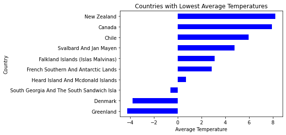

```python
#10 countries with lowest temperatures
ax = country_dta.groupby(['Country'])['AverageTemperature'].last().sort_values(ascending=False).tail(10)
ax = ax.sort_values().plot(kind='barh', color = "blue")
ax.set_xlabel("Average Temperature")
plt.title("Countries with Lowest Average Temperatures")
```

To start off, I decided to plot these two bar graphs to investigate the 10 countries with the highest and lowest average temperatures. This gives us an idea of the two extremes in climate and we can use these countries to compare and contrast the temperature change trends over the years, and observe whether any overlap is present. We can see that the 10 countries with the highest tempratures are geographically placed around the middle east and close to the equator, which logically could have been expected. In contrast, the 10 countries with the lowest average temperatures are placed close to the arctic and antarctic.

### Comparing Data for LandAverageTemperature and LandAndOceanAverageTemperature

###### Figure 3

```python
#scatterplot of LandAverageTemperature and LandAndOceanAverageTemperature over the years 1850-2013
import plotly.express as px
fig = px.scatter(global_temp, x="Year", y=["LandAverageTemperature", 'LandAndOceanAverageTemperature' ],
                 title="Land & Land and Ocean Average Temperature 1850-2013")
py.iplot(fig)
```

[interactive chart not shown]

From this scatterplot we can see that the average temperature of land and ocean starts noticebly increasing around the 1900's, we can see a clear up-trend in average temperatures between 1850 and 2013. We also notice a larger disparity between the land average temperatures compared to the land and ocean temperatures. The temperatures range from around 1-15 degrees celcius for the land average temperature. On the other hand, the land and ocean average temperature data only records temperatures between 12-18 degrees celcius. This furhter proves the earlier hypothesis that 'we might notice bigger changes in land temperature as opposed to water temperature'. Due to this, a larger focus will be placed on the land average temperature in my project as the data is analysed.

Overall, I established a clear result in the increase of temperature. From around the late 1900's we have seen an exponential growth in temperature change compared to the previous century. This can be attributed to many different factors that I will further explore.

## Project 2

Since the beginning of the millennium, close to 1 billion people have been affected by natural disasters. To put this number into perspective, it is over 10% of the entire world population. Several of these disasters have injured people, some even fatally. Natural disasters kill, on average, 60000 people per year. However, this number highly varies from year to year, depending on unpredictable high-impact events. The damage and impact of natural disasters relies heavily on the intensity of the individual incident. Some catastrophic events, such as the 2010 earthquake in Haiti, represent a one-off incident that impacted around 3 million residents. The earthquake caused between 100,000 and 320,000 estimated deaths and widespread damage across Haiti. Such incidents are the reason why we cannot precisely estimate a trend by comparing two years with one another.

Flooding has been the most common natural disaster since the late 1900s. Over the last 30 years, around 10,000 natural disasters occurred globally, 42 percent being floods. Furthermore, storms, such as cyclones, hurricanes, and tornados, accounted for 30 percent of the total. Together, they cover nearly three-quarters of the disasters that have occurred since 1990. It is not a coincidence that global warming has the largest impacts on weather-related natural disasters such as storms and floods. Evidence suggests that climate change is to blame for the growing number of weather-related catastrophes such as droughts, hurricanes, and floods. With climate change creating more severe weather patterns, the risk to disaster-prone cities and regions continues to escalate. Many cities are geographically placed in risky areas. Near coasts, floodplains, and fault lines, making them vulnerable to floods, storms, earthquakes, and other natural hazards. This provides a fiscal strain on governments, due to the costly demands for relief and reconstruction increasing their budget deficits.

In project 2, I will go more into depth with my analysis of temperature changes over time. I will introduce visual maps to showcase my findings in more reader-friendly ways. I will narrow my focus to comparing temperature changes from 1900 to 2000 and 2000 to 2013. As previously discovered, the average temperature of land and ocean commences noticeably increasing around the 1900s, I will use this as my data cut-off. To gain a deeper understanding of the causal effects of temperature increases, I will incorporate an additional dataset. This dataset records the number of natural disasters that struck over the equivalent time frame. I believe there should be an overlap in trends, and we should see very similar graphs for the two.

### Mapping the Average Temperatures for each of the Countries

```python
#average temp for each country
countries = np.unique(country_dta['Country'])
mean_temp = []
for country in countries:
    mean_temp.append(country_dta[country_dta['Country'] == country]['AverageTemperature'].mean())
```

###### Figure 4

```python
#creating map
data = [ dict(
        type = 'choropleth',
        locations = countries,
        z = mean_temp,
        locationmode = 'country names',
        text = countries,
        marker = dict(
            line = dict(color = 'rgb(0,0,0)')), colorbar = dict(title = 'Scale, °C'))
       ]

layout = dict(
    title = 'Average Land Temperature Map',
    geo = dict(
        showocean = True,
        oceancolor = 'rgb(0,250,250)',
        projection = dict(
        type = 'natural earth',
            rotation = dict(lon = 20, lat = 10),
        ),),)

fig = dict(data=data, layout=layout)
py.iplot(fig)
```

[interactive chart not shown]

This map displays the average land temperature around the world. I took the average of each country over the time period of 1850-2013. We can clearly see the hottest areas are situated around the equator and the coldest country, Greenland, is found close to the north pole.

### Finding Which Countries Experienced the Largest Differences in Temperature

```python
year_1900 = gbY.get_group(1900).groupby(['Country'])['AverageTemperature'].mean().reset_index()
year_2000 = gbY.get_group(2000).groupby(['Country'])['AverageTemperature'].mean().reset_index()

difference_1 = pd.merge(left = year_1900, right = year_2000, on = ['Country'])
difference_1['Difference'] = difference_1['AverageTemperature_y'] - difference_1['AverageTemperature_x']
```

###### Figure 5

```python
import plotly.graph_objects as go
fig = go.Figure()
fig.update_layout(title="Difference in Temperatures 1900-2000", title_font_size = 20,
                  template = "ggplot2", autosize = False, height = 2000, width = 1000)

sort_diff = difference_1[['Country', 'Difference']].sort_values(by = 'Difference', ascending = True)
fig.add_trace(go.Bar(x = sort_diff['Difference'], y = sort_diff['Country'], orientation = 'h',
                    marker=dict(color='rgb(200,100,135)')))
fig.show()
```

[interactive chart not shown]

After plotting the chart for the difference in temperatures between the year 1900 and 2000 we can see from the output the temperature trends for every country over time. The countries with the biggest difference in temperature are mostly Scandinavian countries such as, Finalnd, Sweden, Norway as well as northern countries like Estonia. These countries experienced a temperature change of around 3 degrees celcius over these 100 years. On the other side of the scale we have countries which barely had a temperature increase or didn't have one at all. All of these are African and Carribean countries, which are on average associated with high temperatures. This procudes interesting results, suggesting that countries which are located in colder regions experience a more prominent change in temperature compared to counties located in warmer areas e.g. closer to the equator.

###### Figure 6

```python
#Differences in temperatures in the last 13 years
year_2013 = gbY.get_group(2013).groupby(['Country'])['AverageTemperature'].mean().reset_index()

difference_2 = pd.merge(left = year_2000, right = year_2013, on = ['Country'])
difference_2['Difference'] = difference_2['AverageTemperature_y'] - difference_2['AverageTemperature_x']

fig = go.Figure()
fig.update_layout(title="Difference in Temperatures 2000-2013", title_font_size = 20,
                  template = "ggplot2", autosize = False, height = 2000, width = 1000)

sort_diff = difference_2[['Country', 'Difference']].sort_values(by = 'Difference', ascending = True)
fig.add_trace(go.Bar(x = sort_diff['Difference'], y = sort_diff['Country'], orientation = 'h',
                    marker=dict(color='rgb(600,100,135)')))
fig.show()
```

[interactive chart not shown]

Similarly to the bar chart above for the years 1900 to 2000, the chart for the years 2000 to 2013 presents an alike picture. The colder countries experience a larger change in temperatures, while the warmer ones not as much. According to the Norwegian Polar Institute the "Arctic is warming three times as fast and the global average. This is mainly because melting of snow and ice exposes a darker surface and increases the amount of solar energy absorbed in these areas" this is called the albedo effect. Colder countries are surrounded by more sea and land ice, differences in the amount of sea ice can disrupt normal ocean circulation, leading to changes in global climate. Significant increases in regional temperature can lead to continued loss of sea ice and therefore, greater warming over time, making the polar regions the most sensitive areas to climate change on Earth. My analysis supports this idea as we can clearly see from these two charts.

###### Figure 7

```python
#a world map with the changes temperature overtime
d_list = difference_2['Difference'].values.tolist()

data = [ dict(
        type = 'choropleth',
        locations = countries,
        z = d_list,
        locationmode = 'country names',
        text = countries,
        marker = dict(
            line = dict(color = 'rgb(0,0,0)')), colorbar = dict(title = 'Scale, °C'))
       ]

layout = dict(
    title = 'Difference in Temperatures 2000-2013 Map',
    geo = dict(
        showocean = True,
        oceancolor = 'rgb(0,250,250)',
        projection = dict(
        type = 'natural earth',
            rotation = dict( lon = 20, lat = 10),
        ),),)

fig = dict(data=data, layout=layout)
py.iplot(fig)
```

[interactive chart not shown]

From my analysis above of the temperature differences over time, it has become clear that naturally colder countries seem to experience larger impacts in regards to rising temperatures. From the map created, we can clearly see the gradient of temperature differences featured on the map. Countries closer to the arctic such as; Canada, Greenland and Russia, experiencing around 2 degree differences over a 13 year time period. The largest increase was found in Mongolia which stood at around 2.63 degrees C. On the other hand, the countries closer to the equator do not seem to be as affected by land temperature increases.

### Linking to Natural Disasters Data

```python
#natural disasters data
nd_data = pd.read_csv('/Users/emidobak/Desktop/ECO225/Project/Data/number-of-natural-disaster-events.csv')
grouped = nd_data.groupby(nd_data.Entity)
tot_disasters = grouped.get_group('All natural disasters')
tot_disasters.rename(columns = {'Number of disasters (EMDAT (2020))':'Disasters'}, inplace = True)
new_tot_disasters = tot_disasters.drop(columns = ['Code', 'Entity'])
```

###### Figure 8

```python
fig = px.bar(new_tot_disasters, x="Year", y="Disasters", title="Number of Natural Disasters from 1900 to 2013")
py.iplot(fig)
```

[interactive chart not shown]

After importing the dataset on natural disasters between 1900 and 2013, I created a bar chart to investigate the numbers by year. We see an exponential growth pattern until around the early 2000s when the yearly amount of natural disasters reached a peak of 432 disasters in 2005. This correlation is what we would have expected from the previously stated hypothesis, climate change impacts the number of natural disasters. We see matching trends in this figure with figure 3. They have both experienced high growths in the last 20 years. From this chart we don't have much information on what kind of natural disaster dominated during which years. However, we can assume from the general trends that flooding and storms will account for over 50 percent of all disasters.

Overall, I discovered that colder countries tend to be more affected by global warming and experience higher changes in temperature. This is due to the surrounding climate, which warmer countried do not experience. The arctic sea ice is melting and we are loosing aound 13% of it per decade. Predictions estimate that summer ice could be gone as early as 2035, leaving parts of our planet inundated. This is a scary statistic and could very much be our reality if global warming continues exponentially at our current rate. Furthermore, the increase in natural disasters is affecting people's lives and livelihoods. Global warming might not seem scary at 2 degree increases over decades, however it provides countless negative externalities affecting people's everyday lives.

## Project 3

It is difficult to quantify the social costs natural disasters have on our planet. We do so by estimating a dollar amount of damages, the number of people affected, or the death toll. However, additional costs, such as the victim's suffering is difficult to measure. Losing a loved one, a home, your livelihood, or any part of your life in the blink of an eye can be devastating. In this project, I will look more deeply into the severity of natural disasters by investigating the death toll. As well as, adding data on carbon dioxide emission. I think this could be useful for future analysis and when making any conclusions. As we know a major part of global warming can be attributed to air pollution and fossil fuel production. Therefore, by controlling for this factor I can more clearly understand the big picture of the global warming trends. This opens up space for an analysis of the demographics affected by natural disasters. My goal is to find information through webscraping which would allow me to make further conclusions on both these topics. Webscraping is an automated way to extract data and information from websties. It is increasingly being used to create data sets and find information that is required. This can always be done manually but it is usually faster and more efficient to use web scraping. For my project, I will introduce two new tables. These will help my project in collecting information on exactly what type of natural disasters are have most affected the world, and which countries are the largest polluters over the last 40 years. This will help me delve deeper into my analysis of how global warming affects natural disasters.

```python
import requests
from bs4 import BeautifulSoup
```

### Data Scraping for Emission Data

```python
web_url = "https://en.wikipedia.org/wiki/List_of_countries_by_carbon_dioxide_emissions_per_capita"
response = requests.get(web_url)
soup = BeautifulSoup(response.content)
soup_object = BeautifulSoup(response.content)
data_table = soup_object.find_all('table', 'wikitable sortable')[0]
all_values = data_table.find_all('tr')
```

```python
emission_df = pd.DataFrame(columns = ['Country', '1980', '1985', '1990', '2000', '2008', '2009', '2010',
                                      '2011', '2012', '2013', '2014', '2015', '2018'])
ix = 0
for row in all_values[1:]:
    values = row.find_all('td')

    country = values[0].text
    year_1980 = values[1].text
    year_1985 = values[2].text
    year_1990 = values[3].text
    year_2000 = values[4].text
    year_2008 = values[5].text
    year_2009 = values[6].text
    year_2010 = values[7].text
    year_2011 = values[8].text
    year_2012 = values[9].text
    year_2013 = values[10].text
    year_2014 = values[11].text
    year_2015 = values[12].text
    year_2018 = values[13].text

    emission_df.loc[ix] = [country, year_1980, year_1985, year_1990, year_2000, year_2008, year_2009, year_2010,
                           year_2011, year_2012, year_2013, year_2014, year_2015, year_2018]
    ix += 1
```

```python
#convert strings into floats
emission_df['1980'] = pd.to_numeric(emission_df['1980'], errors = 'coerce')
emission_df['1985'] = pd.to_numeric(emission_df['1985'], errors = 'coerce')
emission_df['1990'] = pd.to_numeric(emission_df['1990'], errors = 'coerce')
emission_df['2000'] = pd.to_numeric(emission_df['2000'], errors = 'coerce')
emission_df['2008'] = pd.to_numeric(emission_df['2008'], errors = 'coerce')
emission_df['2009'] = pd.to_numeric(emission_df['2009'], errors = 'coerce')
emission_df['2010'] = pd.to_numeric(emission_df['2010'], errors = 'coerce')
emission_df['2011'] = pd.to_numeric(emission_df['2011'], errors = 'coerce')
emission_df['2012'] = pd.to_numeric(emission_df['2012'], errors = 'coerce')
emission_df['2013'] = pd.to_numeric(emission_df['2013'], errors = 'coerce')
emission_df['2014'] = pd.to_numeric(emission_df['2014'], errors = 'coerce')
emission_df['2015'] = pd.to_numeric(emission_df['2015'], errors = 'coerce')
emission_df['2018'] = pd.to_numeric(emission_df['2018'], errors = 'coerce')
```

```python
#country averages
emission_df['Average Emission'] = emission_df.mean(axis=1, skipna= True, numeric_only = True)
emission_ordered = emission_df.set_index('Country').sort_values(by=['Average Emission'], ascending = False)
emission_ordered
```

| Country | 1980 | 1985 | 1990 | 2000 | 2008 | 2009 | 2010 | 2011 | 2012 | 2013 | 2014 | 2015 | 2018 | Average Emission |
| --- | --- | --- | --- | --- | --- | --- | --- | --- | --- | --- | --- | --- | --- | --- |
| Qatar | 58.5 | 33.4 | 24.7 | 61.9 | 58.6 | 46.7 | 43.5 | 40.7 | 41.2 | 44.6 | 37.8 | 45.4 | 39.4 | 44.338462 |
| Curaçao | NaN | NaN | NaN | NaN | NaN | NaN | NaN | NaN | NaN | 39.4 | 33.9 | 37.7 | 46.7 | 39.425000 |
| Trinidad and Tobago | 15.6 | 17.7 | 13.9 | 13.6 | 18.8 | 33.7 | 34.0 | 36.1 | 35.2 | 33.9 | 34.5 | 34.2 | 26.7 | 26.761538 |
| Kuwait | 18.0 | 16.8 | 24.3 | 34.0 | 26.1 | 31.2 | 31.0 | 29.9 | 28.5 | 30.1 | 27.3 | 25.2 | 24.3 | 26.669231 |
| United Arab Emirates | 35.4 | 35.9 | 28.0 | 28.8 | 35.7 | 22.8 | 21.9 | 19.4 | 19.1 | 19.8 | 19.0 | 23.3 | 22.1 | 25.476923 |
| ... | ... | ... | ... | ... | ... | ... | ... | ... | ... | ... | ... | ... | ... | ... |
| Democratic Republic of the Congo | 0.1 | 0.1 | 0.1 | 0.1 | 0.0 | 0.0 | 0.0 | 0.0 | 0.0 | 0.0 | 0.1 | 0.1 | 0.1 | 0.053846 |
| Chad | 0.0 | 0.0 | 0.0 | 0.0 | 0.0 | 0.0 | 0.0 | 0.0 | 0.0 | 0.0 | 0.1 | 0.1 | 0.0 | 0.015385 |
| Burundi | 0.0 | 0.0 | 0.0 | 0.0 | 0.0 | 0.0 | 0.0 | 0.0 | 0.0 | 0.0 | 0.0 | 0.0 | 0.0 | 0.000000 |
| Faroe Islands | NaN | NaN | 0.0 | NaN | NaN | NaN | NaN | NaN | NaN | NaN | NaN | NaN | 0.0 | 0.000000 |
| United States Virgin Islands | NaN | NaN | NaN | NaN | NaN | NaN | NaN | NaN | NaN | NaN | NaN | NaN | NaN | NaN |

223 rows × 14 columns

```python
emission_ordered.reset_index(inplace = True)
```

###### Figure 9

```python
fig = go.Figure()
fig.update_layout(title="Average Emissions 1980-2018 per Capita", title_font_size = 20,
                  template = "ggplot2", autosize = False, height = 2000, width = 1000)

sort_diff = emission_ordered[['Country','Average Emission']]
fig.add_trace(go.Bar(x = emission_ordered['Average Emission'], y = emission_ordered['Country'], orientation = 'h',
                    marker=dict(color='rgb(600,100,135)')))
fig.show()
```

[interactive chart not shown]

###### Figure 10

```python
#averages over the years
emission_ordered2 = emission_df.mean(axis=0, skipna= True, numeric_only = True)
emission_ordered2
```

```
1980                4.692121
1985                4.035758
1990                4.222162
2000                4.578173
2008                4.672864
2009                4.979412
2010                4.784314
2011                4.870244
2012                4.815122
2013                4.984541
2014                4.881159
2015                4.910784
2018                5.196729
Average Emission    4.906716
dtype: float64
```

### Data Scraping for Number of Deaths

The data that I have chosen to scrape is a compilation of the deadliest natural disasters that occurred over the years. I stuck to the most recent century as it is the most relevant to my analysis. I followed a similar procedure as I did when scraping the previous data. There is no need to run the program regularly as it would only update in the event of a disaster substantial enough to make it onto the list. Due to the publicity such an event would have, the program could be manually re-run when needed.

```python
#death toll data web-scraping
web_url2 = "https://en.wikipedia.org/wiki/List_of_natural_disasters_by_death_toll"
response2 = requests.get(web_url2)
soup_object2 = BeautifulSoup(response2.content)
data_table2 = soup_object2.find_all('table')[1]
all_values2 = data_table2.find_all('tr')
```

```python
death_toll_df = pd.DataFrame(columns = ['Death Toll', 'Event']) # Create an empty dataframe
ix = 0 # Initialise index to zero

for row in all_values2[1:]:
    values = row.find_all('td')

    death_toll = values[0].text.rstrip()
    event = values[1].text.rstrip()

    death_toll_df.loc[ix] = [death_toll, event] # Store it in the dataframe as a row
    ix += 1

death_toll_df
```

|  | Death Toll | Event |
| --- | --- | --- |
| 0 | 422,499–4,000,000[10] | 1931 China floods |
| 1 | 242,000–655,000 | 1976 Tangshan earthquake |
| 2 | 500,000+[1] | 1970 Bhola cyclone |
| 3 | 273,400 | 1920 Haiyuan earthquake |
| 4 | 229,000 | 1975 Typhoon Nina—contributed to Banqiao Dam f... |
| 5 | 227,898 | 2004 Indian Ocean earthquake and tsunami |
| 6 | 100,000–316,000[11] | 2010 Haiti earthquake |
| 7 | 145,000 | 1935 Yangtze flood |
| 8 | 143,000 | 1923 Great Kantō earthquake |
| 9 | 138,866 | 1991 Bangladesh cyclone |

```python
death_toll_df.at[0,'Death Toll']='3,000,000'
death_toll_df.at[1,'Death Toll']='600,000'
death_toll_df.at[2,'Death Toll']='500,000'
death_toll_df.at[4,'Event']='1975 Typhoon Nina'
death_toll_df.at[6,'Death Toll']='200,000'
death_toll_df
```

|  | Death Toll | Event |
| --- | --- | --- |
| 0 | 3,000,000 | 1931 China floods |
| 1 | 600,000 | 1976 Tangshan earthquake |
| 2 | 500,000 | 1970 Bhola cyclone |
| 3 | 273,400 | 1920 Haiyuan earthquake |
| 4 | 229,000 | 1975 Typhoon Nina |
| 5 | 227,898 | 2004 Indian Ocean earthquake and tsunami |
| 6 | 200,000 | 2010 Haiti earthquake |
| 7 | 145,000 | 1935 Yangtze flood |
| 8 | 143,000 | 1923 Great Kantō earthquake |
| 9 | 138,866 | 1991 Bangladesh cyclone |

Additionally after some research, I noticed a negative correlation when plotting the number of deaths from natural disasters over time. Nonetheless, this is not a causal relationship; there are confounding variables that influence the number of deaths. From the analysis in figure 8, we concluded an increase in natural disasters over the past century, which would be counter-intuitive to the decrease in deaths. However, there has been a substantial increase in the efficiency of rescue, evacuation, and damage control when dealing with the repercussions of natural disasters. Over time, we have learned how to be better equipped for unexpected emergencies, helping decrease the death toll. Nonetheless, poverty remains on the rise, presenting itself as a consequential long-term impact of natural disasters. Due to the lack of proper safety measures, infrastructures, and most likely settling in riskier areas for economic reasons, the poor tend to be predominantly targeted by these natural disasters.

One of the main difficulties in assessing the economic impact of natural disasters relates to the valuation of losses. It is hard to measure the effect on nonmarketed goods like the environment. In this case, social efficiency is maximized when we balance the risks, costs, and benefits of disaster management. However, preventing the total loss of livelihoods and poverty should be prioritized. Climate change and exposure to natural hazards have the deepest impacts on people living in poverty, even though they are the least equipped to deal with these situations.

## Final Project

The purpose of the third project is to focus on an exact research question. In this project I will examine the question of “Are Natural Disasters an Indicator of Economic crisis?” When trying to understand what causes economic crises, we encounter a very broad spectrum of reasons and explanations for the question. From the macroeconomic factors such as policy rates, credit creation, and international capital flows, to the financial market factors, such as, bond prices, interest rate levels, and investments. There are countless reasons and triggers for economic downturns, however, in my paper, I am going to use debt as a percentage of GDP to represent the economic crisis. To answer this question, I regressed the number of natural disasters vs debt as a percentage of GDP. Furthermore, throughout this project I will find additional data which is needed to investigate my research question. I introduced three more data sets, namely, greenhouse gas emissions, debt as a percentage of GDP and losses in dollars from natural disasters. The other two datasets I found from the Federal Reserve of Economic Data (FRED).

```python
!pip install linearmodels
```

```python
#importing packages
import statsmodels.api as sm
from statsmodels.iolib.summary2 import summary_col
from linearmodels.iv import IV2SLS
```

```python
#emission data
emission_dta = pd.read_csv('/Users/emidobak/Desktop/ECO225/Project/Data/emission data.csv')

#drop pre 1850's data
emission_dta.drop(emission_dta.iloc[:, 1:100], inplace = True, axis = 1)

#sorting data to match the format
emission_sorted = pd.melt(frame=emission_dta, id_vars=['Country'], var_name='Year', value_name='Emission')
emission_sorted.sort_values(by=['Emission'], ascending=False)
emission_sorted.set_index('Year', inplace=True)
```

```python
#sort new emission data to create df2
new_emission_sorted = emission_sorted.groupby(['Year']).mean()
new_emission_sorted.drop(new_emission_sorted.index[0:50], inplace = True)
new_emission_sorted.drop(new_emission_sorted.index[-2:], inplace = True)
df2 = new_emission_sorted.reset_index()
```

```python
#sort natural disaster data to create df1
new_tot_disasters.drop(new_tot_disasters.index[116:], inplace = True)
df1 = new_tot_disasters
```

```python
#merge dataframes
merged = pd.merge(df1, df2, left_index = True, right_index = True)
merged.drop(labels = 'Year_y', axis = 1, inplace = True)
merged.rename(columns = {'Year_x':'Year'}, inplace = True)

#creating log columns for emission and natural disaster data
merged['log_disasters'] = np.log(merged['Disasters'])
merged['log_emission'] = np.log(merged['Emission'])
```

#### Adding Variables to the Dataset

```python
global_temp2 = global_temp
global_temp2["Year"] = global_temp2["Date"].dt.year
global_temp2.drop(labels = ['Date', 'LandMaxTemperature', 'LandMaxTemperatureUncertainty', 'LandMinTemperature',
                              'LandMinTemperatureUncertainty', 'Month'], axis = 1, inplace = True)
global_temp2 = global_temp2.groupby(['Year']).mean()
global_temp2.drop(global_temp2.index[0:50])
global_temp3 = global_temp2.reset_index()
```

```python
merged2 = pd.merge(merged, global_temp3, left_index = True, right_index = True)
merged2.drop(labels = 'Year_y', axis = 1, inplace = True)
merged2.rename(columns = {'Year_x':'Year'}, inplace = True)
```

I merged the original temperature change data with the new emission data into one data frame so I am able to run regressions on it. This way I am able to use land average temperature, and land and ocean average temperature as my explanatory variables (z) for my 2SLS regressions. The level of observations in the emission dataset was the number of tonnes of Green House Gases different countries emit from year 1750 - 2019. However, my research does not span to pre 1900 data, therefore I dropped the remaining observations focusing my datapoints in the relevant time frame. For the other two datasets I altered the observations to yearly data points vs their suggested quarterly. I chose global debt as a percentage of GDP to be my y-variable, due to the simplicity when providing quantitative and qualitative analysis for my research question

```python
merged2['const'] = 1
```

#### Adding New Data

Additionally I found datasets for debt as a percent of GDP, as well as total monetary damage from natural disasters which I will also be using for my model. Since I am investigating whether natural disasters are a good indicator of economic crisis, I will be using debt as a percentage of GDP as an indicator of economic crisis.

```python
#debt data
pct_debt = pd.read_csv('/Users/emidobak/Desktop/ECO225/Project/Data/GFDEGDQ188S.csv')
pct_debt['year'] = pd.DatetimeIndex(pct_debt['DATE']).year
pct_debt.drop(labels = 'DATE', axis = 1, inplace = True)
pct_debt.rename(columns = {'year':'Year'}, inplace = True)
pct_debt.rename(columns = {'GFDEGDQ188S':'Debt as % of GDP'}, inplace = True)

#losses data
losses_dta = pd.read_csv('/Users/emidobak/Desktop/ECO225/Project/Data/total-damage-natural-disasters.csv')
losses_dta.rename(columns = {'Total':'Losses'}, inplace = True)
```

###### Figure 11

```python
fig = px.bar(losses_dta, x="Year", y="Losses", title="Losses in dollars from Natural Disasters 1966-2015")
py.iplot(fig)
```

[interactive chart not shown]

In this figure we see the losses in dollars from natural disasters over the last 50 years. As we can see there have been recent increases in the financial hardships natural disasters have caused. This is reflected on the increase in natural disaster occurences over the past couple of years as seen in figure 8.

###### Figure 12

```python
fig = px.bar(pct_debt, x="Year", y="Debt as % of GDP", title="Debt as % of GDP 1966-2015")
py.iplot(fig)
```

[interactive chart not shown]

Similarly as in the previous figure we can see an increase in the debt as a percentage of GDP over the past couple of years. The increase has not been as dramatic as in the losses but we can definitely see a correlation between the two figures.

```python
#merge debt as % of GDP and natural disasters losses datasets
losses_and_debt = pd.merge(losses_dta, pct_debt, on = ['Year'])
```

```python
merged3 = pd.merge(merged2, losses_and_debt, on = ['Year'])
```

### OLS Regressions - Finding the IV

One major issue that arises in an ordinary least square (OLS) regression is the correlation between the regressors and the error term, which is often called the problem of endogeneity. Due to endogeneity, the OLS estimates become inconsistent and therefore unreliable (Wooldridge, 2013). To fix this bias I used a 2SLS regression instead of OLS. The extent to which a natural disaster translates into global debt depends on many omitted factors which may differ from country to country, such as the post disaster management and institutional quality, among others. Therefore, it is useful to take endogeneity into account while using the natural disaster dataset to arrive at robust results. I started by finding a good Instrumental Variable (IV) for my independent variable, natural disasters. IV’s estimation is used when the model has endogenous x’s, i.e., if the covariance of the x variable and the error term isn’t zero. The IV addresses the problem of omitted variable bias. To choose the best IV I ran three OLS regressions against disasters, which were, greenhouse gas emissions, global land temperature, and land and ocean average temperature. The regressions are found below.

###### OLS Regression 1

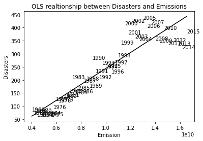

```python
#OLS regression of emissions vs disasters
df1_subset = merged3.dropna(subset=['Disasters', 'Emission'])

X = df1_subset['Emission']
y = df1_subset['Disasters']
labels = df1_subset['Year']

# Replace markers with years
fig, ax = plt.subplots()
ax.scatter(X, y, marker='')

for i, label in enumerate(labels):
    ax.annotate(label, (X.iloc[i], y.iloc[i])) #set the coordinates of the labels

# Fit a linear trend line
ax.plot(np.unique(X),
         np.poly1d(np.polyfit(X, y, 1))(np.unique(X)),
         color='black')

ax.set_xlabel('Emission')
ax.set_ylabel('Disasters')
ax.set_title('OLS realtionship between Disasters and Emissions')

plt.show()
```

As we can see from the results of the OLS regression between disasters and emissions, there is a strong positive linear association. As the emissions increase the disasters become slightly more unpredictable and deviate from the line of best fit, however they still follow the general trend.

```python
#Disasters vs Emissions
reg1 = sm.OLS(endog=merged2['Emission'], exog=merged2[['const', 'Disasters']])
results = reg1.fit()
print(results.summary())
```

```
                            OLS Regression Results
==============================================================================
Dep. Variable:               Emission   R-squared:                       0.936
Model:                            OLS   Adj. R-squared:                  0.935
Method:                 Least Squares   F-statistic:                     1667.
Date:                Sat, 16 Apr 2022   Prob (F-statistic):           6.96e-70
Time:                        22:49:05   Log-Likelihood:                -2584.2
No. Observations:                 116   AIC:                             5172.
Df Residuals:                     114   BIC:                             5178.
Df Model:                           1
Covariance Type:            nonrobust
==============================================================================
                 coef    std err          t      P>|t|      [0.025      0.975]
------------------------------------------------------------------------------
const       1.556e+09   1.38e+08     11.286      0.000    1.28e+09    1.83e+09
Disasters   3.325e+07   8.14e+05     40.829      0.000    3.16e+07    3.49e+07
==============================================================================
Omnibus:                        8.584   Durbin-Watson:                   0.508
Prob(Omnibus):                  0.014   Jarque-Bera (JB):               18.372
Skew:                           0.020   Prob(JB):                     0.000102
Kurtosis:                       4.949   Cond. No.                         217.
==============================================================================

Notes:
[1] Standard Errors assume that the covariance matrix of the errors is correctly specified.
```

###### OLS Regression 2

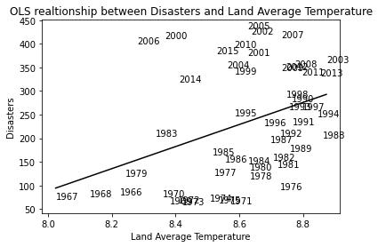

```python
#OLS regression of Land average temperature vs disasters
df2_subset = merged3.dropna(subset=['Disasters', 'LandAverageTemperature'])

X = df2_subset['LandAverageTemperature']
y = df2_subset['Disasters']
labels = df2_subset['Year']

# Replace markers with years
fig, ax = plt.subplots()
ax.scatter(X, y, marker='')

for i, label in enumerate(labels):
    ax.annotate(label, (X.iloc[i], y.iloc[i])) #set the coordinates of the labels

# Fit a linear trend line
ax.plot(np.unique(X),
         np.poly1d(np.polyfit(X, y, 1))(np.unique(X)),
         color='black')

ax.set_xlabel('Land Average Temperature')
ax.set_ylabel('Disasters')
ax.set_title('OLS realtionship between Disasters and Land Average Temperature')

plt.show()
```

As we can see from the results of the OLS regression between disasters vs land average temperature, there is a weak positive linear association. As the land temprature increases the disasters also increase, however there is a lot of variation around the trend line. There is a linear association but it is not as strong as for the previous graph of disasters and emissions.

```python
#disasters vs land average temperature
reg2 = sm.OLS(endog=merged2['LandAverageTemperature'], exog=merged2[['const', 'Disasters']])
results = reg2.fit()
print(results.summary())
```

```
                              OLS Regression Results
==================================================================================
Dep. Variable:     LandAverageTemperature   R-squared:                       0.460
Model:                                OLS   Adj. R-squared:                  0.455
Method:                     Least Squares   F-statistic:                     97.12
Date:                    Sat, 16 Apr 2022   Prob (F-statistic):           6.06e-17
Time:                            22:49:07   Log-Likelihood:                 12.561
No. Observations:                     116   AIC:                            -21.12
Df Residuals:                         114   BIC:                            -15.61
Df Model:                               1
Covariance Type:                nonrobust
==============================================================================
                 coef    std err          t      P>|t|      [0.025      0.975]
------------------------------------------------------------------------------
const          8.1878      0.026    313.331      0.000       8.136       8.240
Disasters      0.0015      0.000      9.855      0.000       0.001       0.002
==============================================================================
Omnibus:                        0.629   Durbin-Watson:                   1.006
Prob(Omnibus):                  0.730   Jarque-Bera (JB):                0.506
Skew:                          -0.162   Prob(JB):                        0.776
Kurtosis:                       2.985   Cond. No.                         217.
==============================================================================

Notes:
[1] Standard Errors assume that the covariance matrix of the errors is correctly specified.
```

###### OLS Regression 3

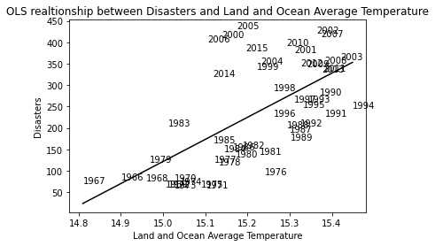

```python
#OLS regression of Land average temperature vs disasters
df3_subset = merged3.dropna(subset=['Disasters', 'LandAndOceanAverageTemperature'])

X = df3_subset['LandAndOceanAverageTemperature']
y = df3_subset['Disasters']
labels = df3_subset['Year']

# Replace markers with years
fig, ax = plt.subplots()
ax.scatter(X, y, marker='')

for i, label in enumerate(labels):
    ax.annotate(label, (X.iloc[i], y.iloc[i])) #set the coordinates of the labels

# Fit a linear trend line
ax.plot(np.unique(X),
         np.poly1d(np.polyfit(X, y, 1))(np.unique(X)),
         color='black')

ax.set_xlabel('Land and Ocean Average Temperature')
ax.set_ylabel('Disasters')
ax.set_title('OLS realtionship between Disasters and Land and Ocean Average Temperature')

plt.show()
```

This graph is very similar to the previous graph for land average temperature. It has a very similar weak positive correlation and large variation around the line of best fit.

```python
#disasters vs land and ocean average temperature
reg3 = sm.OLS(endog=merged2['LandAndOceanAverageTemperature'], exog=merged2[['const', 'Disasters']])
results = reg3.fit()
print(results.summary())
```

```
                                  OLS Regression Results
==========================================================================================
Dep. Variable:     LandAndOceanAverageTemperature   R-squared:                       0.549
Model:                                        OLS   Adj. R-squared:                  0.545
Method:                             Least Squares   F-statistic:                     138.6
Date:                            Sat, 16 Apr 2022   Prob (F-statistic):           2.01e-21
Time:                                    22:49:11   Log-Likelihood:                 81.319
No. Observations:                             116   AIC:                            -158.6
Df Residuals:                                 114   BIC:                            -153.1
Df Model:                                       1
Covariance Type:                        nonrobust
==============================================================================
                 coef    std err          t      P>|t|      [0.025      0.975]
------------------------------------------------------------------------------
const         14.9586      0.014   1035.498      0.000      14.930      14.987
Disasters      0.0010   8.53e-05     11.773      0.000       0.001       0.001
==============================================================================
Omnibus:                        0.278   Durbin-Watson:                   0.883
Prob(Omnibus):                  0.870   Jarque-Bera (JB):                0.172
Skew:                           0.094   Prob(JB):                        0.918
Kurtosis:                       2.997   Cond. No.                         217.
==============================================================================

Notes:
[1] Standard Errors assume that the covariance matrix of the errors is correctly specified.
```

Similarly to the previous OLS output summary the land and ocean average temperature is a decent predictor of natural disasters. However, we notice a slightly higher R-squared value, this reveals that 55% of the data fits the regression model, comparing to 46% for the land average temperature. The p value is the same suggesting we have a strong result for our regression. This comparison between OLS regression 2 and 3 proves one of the earlier theories that the combination of land and ocean surface temperature data is a better indicator of global warming.

Overall, the linear correlation with the endogenous variable was the highest for disasters vs emissions. Intuitively we know that debt is not correlated with emissions, the only effect emissions have on global debt is through their effect on natural disasters. Therefore, greenhouse gas emissions are the best instrument for our model out of the three.

### OLS Regression - Disasters vs Debt as a % of GDP

###### Figure 13

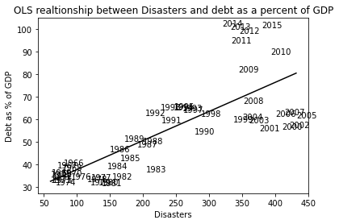

```python
#OLS regression of log_emissions vs log_disasters
df4_subset = merged3.dropna(subset=['Disasters', 'Debt as % of GDP'])

X = df4_subset['Disasters']
y = df4_subset['Debt as % of GDP']
labels = df4_subset['Year']

# Replace markers with years
fig, ax = plt.subplots()
ax.scatter(X, y, marker='')

for i, label in enumerate(labels):
    ax.annotate(label, (X.iloc[i], y.iloc[i])) #set the coordinates of the labels

# Fit a linear trend line
ax.plot(np.unique(X),
         np.poly1d(np.polyfit(X, y, 1))(np.unique(X)),
         color='black')

ax.set_xlabel('Disasters')
ax.set_ylabel('Debt as % of GDP')
ax.set_title('OLS realtionship between Disasters and debt as a percent of GDP')

plt.show()
```

This plot is an OLS regression of natural disasters vs debt as a percentage of GDP. We notice a positive linear association between the two variables. As the number of disasters increases for the years 1966 - 2015 so does the debt as a percentage fo GDP. Furthermore, I will find the OLS summary to asses this relationship.

A regression model provides a function that describes the relationship between one or more independent variables and a response, dependent, or target variable

Given the plot, choosing a linear model to describe this relationship seems like a reasonable assumption.

We can write our model as

$$ {Debt}_i = \beta_0 + \beta_1 {Disasters}_i + u_i $$

where:

- $ \beta_0 $ is the intercept of the linear trend line on the y-axis
- $ \beta_1 $ is the slope of the linear trend line, representing the *marginal effect* of disasters on the debt as a percentage of GDP
- $ u_i $ is a random error term (deviations of observations from the linear trend due to factors not included in the model)

```python
reg4 = sm.OLS(endog=merged3['Debt as % of GDP'], exog=merged3[['const', 'Disasters']])
results = reg4.fit()
print(results.summary())
```

```
                            OLS Regression Results
==============================================================================
Dep. Variable:       Debt as % of GDP   R-squared:                       0.580
Model:                            OLS   Adj. R-squared:                  0.571
Method:                 Least Squares   F-statistic:                     66.18
Date:                Sat, 16 Apr 2022   Prob (F-statistic):           1.38e-10
Time:                        22:49:15   Log-Likelihood:                -200.21
No. Observations:                  50   AIC:                             404.4
Df Residuals:                      48   BIC:                             408.2
Df Model:                           1
Covariance Type:            nonrobust
==============================================================================
                 coef    std err          t      P>|t|      [0.025      0.975]
------------------------------------------------------------------------------
const         24.9294      4.064      6.135      0.000      16.759      33.100
Disasters      0.1287      0.016      8.135      0.000       0.097       0.161
==============================================================================
Omnibus:                        6.513   Durbin-Watson:                   0.198
Prob(Omnibus):                  0.039   Jarque-Bera (JB):                5.498
Skew:                           0.769   Prob(JB):                       0.0640
Kurtosis:                       3.521   Cond. No.                         545.
==============================================================================

Notes:
[1] Standard Errors assume that the covariance matrix of the errors is correctly specified.
```

Using our parameter estimates, we can now write our estimated relationship as:

$$ \widehat{Debt}_i = 24.93 + 0.13 \ {Disasters}_i $$

This equation describes the line that best fits our data, as shown in the figure above.

### Multivariate Regression Model

```python
# Create lists of variables to be used in each regression
X1 = ['const', 'Emission']
X2 = ['const', 'Emission', 'LandAverageTemperature']
X3 = ['const', 'Emission', 'LandAverageTemperature', 'LandAndOceanAverageTemperature']

# Estimate an OLS regression for each set of variables
reg1 = sm.OLS(merged3['Disasters'], merged3[X1], missing='drop').fit()
reg2 = sm.OLS(merged3['Disasters'], merged3[X2], missing='drop').fit()
reg3 = sm.OLS(merged3['Disasters'], merged3[X3], missing='drop').fit()
```

```python
from statsmodels.iolib.summary2 import summary_col
info_dict={'R-squared' : lambda x: f"{x.rsquared:.2f}",
           'No. observations' : lambda x: f"{int(x.nobs):d}"}
```

```python
results_table = summary_col(results=[reg1,reg2,reg3],
                            float_format='%0.2f',
                            stars = True,
                            model_names=['Model 1',
                                         'Model 3',
                                         'Model 4'],
                            info_dict=info_dict,
                            regressor_order=['const',
                                             'Emission',
                                             'LandAverageTemperature',
                                             'LandAndOceanAverageTemperature'])

results_table.add_title('OLS Regression 1')

print(results_table)
```

```
                      OLS Regression 1
=============================================================
                                Model 1  Model 3    Model 4
-------------------------------------------------------------
const                          -60.57*** 126.46   -4182.85***
                               (18.43)   (320.15) (1313.92)
Emission                       0.00***   0.00***  0.00***
                               (0.00)    (0.00)   (0.00)
LandAverageTemperature                   -22.35   -269.57***
                                         (38.20)  (81.25)
LandAndOceanAverageTemperature                    426.44***
                                                  (126.82)
R-squared                      0.85      0.85     0.88
R-squared Adj.                 0.85      0.85     0.88
R-squared                      0.85      0.85     0.88
No. observations               50        50       50
=============================================================
Standard errors in parentheses.
* p<.1, ** p<.05, ***p<.01
```

### Multivariate Regression Model 2

```python
# Create lists of variables to be used in each regression
A1 = ['const', 'Disasters']
A2 = ['const', 'Disasters', 'Losses']
A3 = ['const', 'Disasters', 'Losses', 'LandAverageTemperature']
A4 = ['const', 'Disasters', 'Losses', 'LandAverageTemperature', 'Emission']

# Estimate an OLS regression for each set of variables
reg5 = sm.OLS(merged3['Debt as % of GDP'], merged3[A1], missing='drop').fit()
reg6 = sm.OLS(merged3['Debt as % of GDP'], merged3[A2], missing='drop').fit()
reg7 = sm.OLS(merged3['Debt as % of GDP'], merged3[A3], missing='drop').fit()
reg8 = sm.OLS(merged3['Debt as % of GDP'], merged3[A4], missing='drop').fit()

info_dict={'R-squared' : lambda x: f"{x.rsquared:.2f}",
           'No. observations' : lambda x: f"{int(x.nobs):d}"}
```

```python
results_table2 = summary_col(results=[reg5,reg6,reg7,reg8],
                            float_format='%0.2f',
                            stars = True,
                            model_names=['Model 1',
                                         'Model 2',
                                         'Model 3',
                                         'Model 4'],
                            info_dict=info_dict,
                            regressor_order=['const',
                                             'Disasters',
                                             'Losses',
                                             'LandAverageTemperature',
                                             'Emission'])

results_table2.add_title('OLS Regressions 2')

print(results_table2)
```

```
                    OLS Regressions 2
=========================================================
                       Model 1  Model 2  Model 3 Model 4
---------------------------------------------------------
const                  24.93*** 27.51*** -12.36  66.44
                       (4.06)   (3.89)   (85.35) (44.86)
Disasters              0.13***  0.09***  0.09*** -0.10***
                       (0.02)   (0.02)   (0.02)  (0.02)
Losses                          0.00***  0.00*** 0.00
                                (0.00)   (0.00)  (0.00)
LandAverageTemperature                   4.71    -7.83
                                         (10.07) (5.35)
Emission                                         0.00***
                                                 (0.00)
R-squared              0.58     0.64     0.64    0.91
R-squared Adj.         0.57     0.63     0.62    0.90
R-squared              0.58     0.64     0.64    0.91
No. observations       50       50       50      50
=========================================================
Standard errors in parentheses.
* p<.1, ** p<.05, ***p<.01
```

### Endogeneity - 2SLS

As we appear to have a valid instrument, we can use 2SLS regression to obtain consistent and unbiased parameter estimates.

**First stage**

The first stage involves regressing the endogenous variable ($ {Disasters}_i $) on the instrument.

The instrument is the set of all exogenous variables in our model (and not just the variable we have replaced).

Using model 1 as an example, our instrument is simply a constant and greenhouse gas emissions $ {Emission}_i $.

Therefore, we will estimate the first-stage regression as

$$ {Disasters}_i = \delta_0 + \delta_1 {Emission}_i + v_i $$

```python
# Fit the first stage regression and print summary
results_fs = sm.OLS(merged3['Disasters'],
                    merged3[['const', 'Emission']],
                    missing='drop').fit()
print(results_fs.summary())
```

```
                            OLS Regression Results
==============================================================================
Dep. Variable:              Disasters   R-squared:                       0.853
Model:                            OLS   Adj. R-squared:                  0.850
Method:                 Least Squares   F-statistic:                     279.5
Date:                Sat, 16 Apr 2022   Prob (F-statistic):           1.20e-21
Time:                        22:49:21   Log-Likelihood:                -262.73
No. Observations:                  50   AIC:                             529.5
Df Residuals:                      48   BIC:                             533.3
Df Model:                           1
Covariance Type:            nonrobust
==============================================================================
                 coef    std err          t      P>|t|      [0.025      0.975]
------------------------------------------------------------------------------
const        -60.5723     18.427     -3.287      0.002     -97.622     -23.522
Emission    3.047e-08   1.82e-09     16.717      0.000    2.68e-08    3.41e-08
==============================================================================
Omnibus:                        3.641   Durbin-Watson:                   0.627
Prob(Omnibus):                  0.162   Jarque-Bera (JB):                2.562
Skew:                           0.461   Prob(JB):                        0.278
Kurtosis:                       3.615   Cond. No.                     2.79e+10
==============================================================================

Notes:
[1] Standard Errors assume that the covariance matrix of the errors is correctly specified.
[2] The condition number is large, 2.79e+10. This might indicate that there are
strong multicollinearity or other numerical problems.
```

```python
# Fit the first stage regression and print summary
results_fs2 = sm.OLS(merged3['Disasters'],
                    merged3[['const', 'Emission', 'LandAverageTemperature', 'LandAndOceanAverageTemperature']],
                    missing='drop').fit()
print(results_fs2.summary())
```

```
                            OLS Regression Results
==============================================================================
Dep. Variable:              Disasters   R-squared:                       0.883
Model:                            OLS   Adj. R-squared:                  0.876
Method:                 Least Squares   F-statistic:                     115.9
Date:                Sat, 16 Apr 2022   Prob (F-statistic):           1.85e-21
Time:                        22:49:21   Log-Likelihood:                -257.06
No. Observations:                  50   AIC:                             522.1
Df Residuals:                      46   BIC:                             529.8
Df Model:                           3
Covariance Type:            nonrobust
==================================================================================================
                                     coef    std err          t      P>|t|      [0.025      0.975]
--------------------------------------------------------------------------------------------------
const                          -4182.8525   1313.917     -3.183      0.003   -6827.630   -1538.075
Emission                        2.565e-08   2.44e-09     10.509      0.000    2.07e-08    3.06e-08
LandAverageTemperature          -269.5675     81.251     -3.318      0.002    -433.117    -106.018
LandAndOceanAverageTemperature   426.4353    126.816      3.363      0.002     171.168     681.702
==============================================================================
Omnibus:                        8.531   Durbin-Watson:                   0.870
Prob(Omnibus):                  0.014   Jarque-Bera (JB):                7.897
Skew:                           0.777   Prob(JB):                       0.0193
Kurtosis:                       4.172   Cond. No.                     2.19e+12
==============================================================================

Notes:
[1] Standard Errors assume that the covariance matrix of the errors is correctly specified.
[2] The condition number is large, 2.19e+12. This might indicate that there are
strong multicollinearity or other numerical problems.
```

**Second stage**

Retrieved the predicted values of $ {Disasters}_i $ using the predict function

Then I replaced the endogenous variable $ {Disasters}_i $ with the predicted values $ \widehat{Disasters}_i $ in the original linear model.

Our second stage regression is thus

$$ {Debt}_i = \beta_0 + \beta_1 \widehat{Disasters}_i + u_i $$

```python
merged3['predicted_disasters'] = results_fs.predict()

results_ss = sm.OLS(merged3['Debt as % of GDP'],
                    merged3[['const', 'predicted_disasters']]).fit()
print(results_ss.summary())
```

```
                            OLS Regression Results
==============================================================================
Dep. Variable:       Debt as % of GDP   R-squared:                       0.846
Model:                            OLS   Adj. R-squared:                  0.843
Method:                 Least Squares   F-statistic:                     264.1
Date:                Sat, 16 Apr 2022   Prob (F-statistic):           3.80e-21
Time:                        22:49:22   Log-Likelihood:                -175.07
No. Observations:                  50   AIC:                             354.1
Df Residuals:                      48   BIC:                             358.0
Df Model:                           1
Covariance Type:            nonrobust
=======================================================================================
                          coef    std err          t      P>|t|      [0.025      0.975]
---------------------------------------------------------------------------------------
const                  15.9507      2.617      6.096      0.000      10.689      21.212
predicted_disasters     0.1684      0.010     16.252      0.000       0.148       0.189
==============================================================================
Omnibus:                       10.607   Durbin-Watson:                   0.116
Prob(Omnibus):                  0.005   Jarque-Bera (JB):                2.875
Skew:                           0.026   Prob(JB):                        0.238
Kurtosis:                       1.826   Cond. No.                         571.
==============================================================================

Notes:
[1] Standard Errors assume that the covariance matrix of the errors is correctly specified.
```

```python
iv = IV2SLS(dependent = merged3['Debt as % of GDP'],
            exog = merged3['const'],
            endog = merged3['Disasters'],
            instruments = merged3['Emission']).fit(cov_type = 'unadjusted')

print(iv.summary)
```

```
                          IV-2SLS Estimation Summary
==============================================================================
Dep. Variable:       Debt as % of GDP   R-squared:                      0.5246
Estimator:                    IV-2SLS   Adj. R-squared:                 0.5147
No. Observations:                  50   F-statistic:                    89.009
Date:                Sat, Apr 16 2022   P-value (F-stat)                0.0000
Time:                        22:49:24   Distribution:                  chi2(1)
Cov. Estimator:            unadjusted

                             Parameter Estimates
==============================================================================
            Parameter  Std. Err.     T-stat    P-value    Lower CI    Upper CI
------------------------------------------------------------------------------
const          15.951     4.5077     3.5386     0.0004      7.1158      24.786
Disasters      0.1684     0.0178     9.4345     0.0000      0.1334      0.2034
==============================================================================

Endogenous: Disasters
Instruments: Emission
Unadjusted Covariance (Homoskedastic)
Debiased: False
```

In this project I have established the increases in global land temperature as well as, land and ocean temperatures over time. We can conclude the increases in global temperature are affected by pollution and greenhouse gas emissions. These two factors have the power to create numerous adverse effects both environmentally as well as economically. The main impact this creates is the occurrences of natural disasters. We can see that natural disasters may drive a world economy into a large amount of debt and devastations, similarly to the situation in Dominica in 2017. Global debt is an interesting concept which has been extremely prominent these past years. With the recent COVID-19 pandemic we observed the largest “one-year debt surge since World War II, with global debt rising to $226 trillion as the world was hit by a global health crisis and a deep recession” (Gaspar, et al., 2021). We cannot assume a strict relationship between natural disasters and public debt as there are countless confounding variables that impact debt. However, we may say that the rising of global temperatures and increasing emissions are indirectly affecting public debt through the increase in natural disasters.

In conclusion, the equation I found to represent the relationship between natural disasters and debt as a percentage of GDP is:

$$ {Debt}_i = 15.95 + 0.17 \widehat{Disasters}_i + u_i $$

Implying there is a positive linear association between the two variables, as the number of natural disasters increases so does the global public debt.

There are a number of future questions that should be investigated in this area of study. The rapidly evolving global climate is progressively getting worse and presenting as a critical cause for concern. According to Fankhauser (1995), health experts expect a rise in climate related diseases, such as heat strokes, and a spread of vector-borne diseases like malaria into so far unaffected areas. This is still very relevant today. We have seen spikes in heat related deaths, as well as famines due to crop and water shortages in the summers. Investigating the idea behind whether the death toll of natural disasters is actually decreasing despite the increases in occurrences could be a very interesting and important question to look into.